# NumpySummary

### How to select elements from an Array & assign to them specific values

```python
data1[data1 <0] = 0
data1
```

```
array([[0.        , 0.19109978, 0.        , 0.58541127],
       [2.24314105, 0.16887286, 0.28636763, 0.        ],
       [0.19517702, 0.28190835, 0.41445569, 2.01026978],
       [1.32764669, 0.        , 0.36527108, 0.        ],
       [0.41975575, 0.        , 1.14074437, 2.63043954],
       [0.        , 0.        , 0.32879462, 0.73104998],
       [0.        , 0.20104195, 0.        , 0.        ]])
```

```python
# The matching True values for one array
# can be used to filter/match values on a different array
data1[names == 'Bob'] = 7 # When you found a value which is True you replace with a 7
data1
```

```
array([[7.        , 7.        , 7.        , 7.        ],
       [2.24314105, 0.16887286, 0.28636763, 0.        ],
       [0.19517702, 0.28190835, 0.41445569, 2.01026978],
       [7.        , 7.        , 7.        , 7.        ],
       [0.41975575, 0.        , 1.14074437, 2.63043954],
       [0.        , 0.        , 0.32879462, 0.73104998],
       [0.        , 0.20104195, 0.        , 0.        ]])
```

```python
arr6 = np.empty([8,4]) # It creates an empty array
arr6
# The array it is actually empty the values are not 0 altough the graphical representation seems like it
```

```
array([[1.28622269e+248, 3.66914715e-062, 1.88188514e+219,
        3.62466965e+228],
       [1.39806872e-152, 3.10057194e+169, 7.35989720e+223,
        2.97777909e-260],
       [9.71200179e+189, 3.32304084e-027, 2.79648831e-085,
        5.73351769e+169],
       [1.49341629e+195, 5.26261888e+170, 1.81645474e+223,
        1.49341629e+195],
       [1.70886754e+214, 4.26710252e-090, 3.64852395e+228,
        4.73878089e-085],
       [2.51711125e+180, 1.42101204e+021, 8.79716949e+199,
        9.08610946e+227],
       [2.79437468e+276, 1.47233588e+069, 7.43443095e+247,
        9.08367229e+223],
       [2.99370774e-245, 6.01347002e-154, 2.98573723e-260,
        6.01347002e-154]])
```

```python
# Fill an array by rows

for i in range(8):
    arr6[i] = i # what i am doing is assigning i to each of the elements in each row in the array
arr6
```

```
array([[0., 0., 0., 0.],
       [1., 1., 1., 1.],
       [2., 2., 2., 2.],
       [3., 3., 3., 3.],
       [4., 4., 4., 4.],
       [5., 5., 5., 5.],
       [6., 6., 6., 6.],
       [7., 7., 7., 7.]])
```

```python
arr6[[4,3,0,6]] # it selects the rows I am requesting
```

```
array([[4., 4., 4., 4.],
       [3., 3., 3., 3.],
       [0., 0., 0., 0.],
       [6., 6., 6., 6.]])
```

```python
arr6[[-3,-5,-7]] # it selects the rows but in this case starting from the bottom
```

```
array([[5., 5., 5., 5.],
       [3., 3., 3., 3.],
       [1., 1., 1., 1.]])
```

```python
# Fill an array by columns

for i in range(4):
    arr6[:,i] = i # in this case I assigning the same value to the elements in the column instead of the row
arr6
```

```
array([[0., 1., 2., 3.],
       [0., 1., 2., 3.],
       [0., 1., 2., 3.],
       [0., 1., 2., 3.],
       [0., 1., 2., 3.],
       [0., 1., 2., 3.],
       [0., 1., 2., 3.],
       [0., 1., 2., 3.]])
```

```python
arr7 = np.arange(32).reshape(8,4)
# It takes a sequence of values and converts them into a matrix
arr7
```

```
array([[ 0,  1,  2,  3],
       [ 4,  5,  6,  7],
       [ 8,  9, 10, 11],
       [12, 13, 14, 15],
       [16, 17, 18, 19],
       [20, 21, 22, 23],
       [24, 25, 26, 27],
       [28, 29, 30, 31]])
```

```python
# How to select an element in an array
print (arr7[1,0] )
print (arr7[1][0])
```

```
4
4
```

```python
print (arr7[[1,5,7,2], # this vector gives you the row position
     [0,3,1,2]]) # the vector gives you the column position

# It is equivalent to individually select:
print (arr7[1,0])
print (arr7[5,3])
print (arr7[7,1])
print (arr7[2,2])
```

```
[ 4 23 29 10]
4
23
29
10
```

### Select sub arrays and change the arrays order

```python
# The 1st vector picks rows and the 2nd one scramble the numbers on each row
arr7[[1,5,7,2]][:,[0,3,1,2]]
```

```
array([[ 4,  7,  5,  6],
       [20, 23, 21, 22],
       [28, 31, 29, 30],
       [ 8, 11,  9, 10]])
```

```python
# same as previous but using a built in function
arr7[np.ix_([1,5,7,2], [0,3,1,2])]
```

```
array([[ 4,  7,  5,  6],
       [20, 23, 21, 22],
       [28, 31, 29, 30],
       [ 8, 11,  9, 10]])
```

```python
arr8 = np.arange(15).reshape((3,5))
arr8
```

```
array([[ 0,  1,  2,  3,  4],
       [ 5,  6,  7,  8,  9],
       [10, 11, 12, 13, 14]])
```

```python
arr8.T # The T method transposes the array, don't forget it is an array not a matrix
```

```
array([[ 0,  5, 10],
       [ 1,  6, 11],
       [ 2,  7, 12],
       [ 3,  8, 13],
       [ 4,  9, 14]])
```

```python
arr9 = np.random.randn(6,3)
arr9
```

```
array([[ 1.94318177,  0.19258265,  1.05871338],
       [ 1.3289166 , -1.72538806,  1.74397831],
       [ 0.46605775,  0.17926527,  1.92061843],
       [ 0.09666881, -0.91919246,  0.71589901],
       [ 0.21886069, -1.11781931,  0.26726118],
       [-2.37371169, -2.08968694, -0.01328446]])
```

```python
np.dot(arr9.T, arr9) # Matrix multiplication
```

```
array([[11.45093659,  2.79168461,  5.42922492],
       [ 2.79168461,  9.50741433, -3.38988765],
       [ 5.42922492, -3.38988765,  8.43522595]])
```

```python
arr10 = np.arange(16).reshape((2,2,4))
# Notation: (2,2,4)
# 2: number of vectors
# 2: number of rows
# 4: number of columns
arr10
```

```
array([[[ 0,  1,  2,  3],
        [ 4,  5,  6,  7]],

       [[ 8,  9, 10, 11],
        [12, 13, 14, 15]]])
```

```python
arr10.swapaxes(1,2) # it swaps the axis of the vectors
```

```
array([[[ 0,  4],
        [ 1,  5],
        [ 2,  6],
        [ 3,  7]],

       [[ 8, 12],
        [ 9, 13],
        [10, 14],
        [11, 15]]])
```

### Complex Arrays -- Structure arrays

```python
dt = np.dtype([('Name', 'S10'), ('Age', 'i4'),
               ('Height', 'f'), ('Children/Pets', 'i4', 2)])
s = np.array([('Smith', 45, 1.83, (0, 1)),
              ('Jones', 53, 1.72, (2, 2))], dtype=dt)
s
```

```
array([(b'Smith', 45, 1.83, [0, 1]), (b'Jones', 53, 1.72, [2, 2])],
      dtype=[('Name', 'S10'), ('Age', '<i4'), ('Height', '<f4'), ('Children/Pets', '<i4', (2,))])
```

#### The dt array defines the type of field/data type for each element/pair on the s vector

```python
s['Name']
```

```
array([b'Smith', b'Jones'], dtype='|S10')
```

```python
s['Height'].mean()
```

```
1.7750001
```

```python
s[1]['Age']
```

```
53
```

### Numpy data manipulation

```python
# Outcome of data manipulation of a normal Python array
l = [ 0. ,  0.5,  1.5,  3. ,  5. ]
2 * l
```

```
[0.0, 0.5, 1.5, 3.0, 5.0, 0.0, 0.5, 1.5, 3.0, 5.0]
```

```python
# Outcome of data manipulation of Numpy array
l = np.array(l)
print (l * 2)
print (l ** 2)
```

```
[ 0.  1.  3.  6. 10.]
[ 0.    0.25  2.25  9.   25.  ]
```

```python
g = np.linspace(5, 10, 15)
print (g)
print ('Parameters: Start, Stop, Number of data points between start and stop point')
```

```
[ 5.          5.35714286  5.71428571  6.07142857  6.42857143  6.78571429
  7.14285714  7.5         7.85714286  8.21428571  8.57142857  8.92857143
  9.28571429  9.64285714 10.        ]
Parameters: Start, Stop, Number of data points between start and stop point
```

### Basic Algebra

```python
a = np.array([1, 2, 3])
b = np.array([2, 3, 4])
```

```python
a * b # element wise product
```

```
array([ 2,  6, 12])
```

```python
np.dot(a,b) # Matrix multiplication
```

```
20
```

```python
np.inner(a,b) # Matrix similar
```

```
20
```

```python
o = np.outer(a,b) # It multiplies each element of vector b by each element of vector a
o
```

```
array([[ 2,  3,  4],
       [ 4,  6,  8],
       [ 6,  9, 12]])
```

```python
np.linalg.matrix_power(o, 2)  # matrix power o ** 2
```

```
array([[ 40,  60,  80],
       [ 80, 120, 160],
       [120, 180, 240]])
```

```python
np.linalg.eigvals(o)  # eigenvalues
```

```
array([2.00000000e+01, 3.72357428e-17, 0.00000000e+00])
```

```python
np.linalg.eig(o)  # eigenvalues + right eigenvectors
```

```
(array([2.00000000e+01, 3.72357428e-17, 0.00000000e+00]),
 array([[-0.26726124,  0.01384887,  0.14074157],
        [-0.53452248, -0.80323473, -0.82453357],
        [-0.80178373,  0.59550161,  0.54802939]]))
```

```python
np.linalg.norm(o, ord=1)  # norm of order 1
```

```
24.0
```

```python
np.linalg.norm(o, ord=2)  # norm of order 2 (default)
```

```
20.149441679609886
```

```python
np.linalg.norm(o, axis=0)  # along first axis
```

```
array([ 7.48331477, 11.22497216, 14.96662955])
```

```python
np.linalg.norm(o, axis=1)  # along second axis
```

```
array([ 5.38516481, 10.77032961, 16.15549442])
```

```python
arr11 = np.random.randn(5,4)
arr11
```

```
array([[ 0.64868326, -1.82310812, -0.63547463,  0.59129274],
       [-2.57266044, -0.11402686, -1.53624334,  0.64504161],
       [-0.45444123,  1.18040402,  0.84515131,  0.57880726],
       [-1.37973508,  1.65494751,  0.40588145, -1.31944496],
       [-1.89506936,  1.62211967, -1.37572102,  0.98224441]])
```

```python
print (arr11.mean()) # option 1
print (np.mean(arr11)) #option 2
```

```
-0.19756759013257502
-0.19756759013257502
```

```python
print (arr11.sum() )
print (np.sum(arr11))
```

```
-3.9513518026515
-3.9513518026515
```

```python
# ROWS Mean
arr11.mean(axis = 1)
```

```
array([-0.30465169, -0.89447226,  0.53748034, -0.15958777, -0.16660658])
```

```python
# COLUMNS Mean
arr11.mean(axis = 0)
```

```
array([-1.13064457,  0.50406724, -0.45928125,  0.29558821])
```

```python
arr12 = np.array([[1,2,3], [4,5,6], [7,8,9]])
arr12
```

```
array([[1, 2, 3],
       [4, 5, 6],
       [7, 8, 9]])
```

```python
print ('Cumulative Sum by column')
print (arr12.cumsum(0))
print ('Cumulative Sum by row')
print (arr12.cumsum(1))
```

```
Cumulative Sum by column
[[ 1  2  3]
 [ 5  7  9]
 [12 15 18]]
Cumulative Sum by row
[[ 1  3  6]
 [ 4  9 15]
 [ 7 15 24]]
```

```python
print ('Cumulative Product by column')
print (arr12.cumprod(0))
print ('Cumulative Product by row')
print (arr12.cumprod(1))
```

```
Cumulative Product by column
[[  1   2   3]
 [  4  10  18]
 [ 28  80 162]]
Cumulative Product by row
[[  1   2   6]
 [  4  20 120]
 [  7  56 504]]
```

### Most common methods:

sum, mean, std, var, min,max, argmin, argmax, cumsum, cumprod, exp, sqrt

### Arrays comparison

```python
arrA = np.random.randn(8)
arrB = np.random.randn(8)
```

```python
np.maximum(arrA, arrB)
```

```
array([ 1.41827876, -0.10731533, -0.13940644,  0.81036035, -0.05019124,
        0.28942467, -0.17723123,  0.4110598 ])
```

```python
arrA
```

```
array([-0.38808802, -0.10731533, -0.54355473,  0.81036035, -0.05019124,
       -0.02396009, -0.17723123,  0.4110598 ])
```

```python
# Integer & Decimal components of a number

np.modf(arrA) # it breaks the number into the decimals and the integer components. Creates 2 different arrays
```

```
(array([-0.38808802, -0.10731533, -0.54355473,  0.81036035, -0.05019124,
        -0.02396009, -0.17723123,  0.4110598 ]),
 array([-0., -0., -0.,  0., -0., -0., -0.,  0.]))
```

### How to create vectors and meshgrid

```python
points = np.arange(-1, 1, 0.01) # it creates a 1D vector
```

```python
xs,ys = np.meshgrid(points, points) # it creates a 2D vector combining the 1D
```

```python
xs
```

```
array([[-1.  , -0.99, -0.98, ...,  0.97,  0.98,  0.99],
       [-1.  , -0.99, -0.98, ...,  0.97,  0.98,  0.99],
       [-1.  , -0.99, -0.98, ...,  0.97,  0.98,  0.99],
       ...,
       [-1.  , -0.99, -0.98, ...,  0.97,  0.98,  0.99],
       [-1.  , -0.99, -0.98, ...,  0.97,  0.98,  0.99],
       [-1.  , -0.99, -0.98, ...,  0.97,  0.98,  0.99]])
```

```python
ys
```

```
array([[-1.  , -1.  , -1.  , ..., -1.  , -1.  , -1.  ],
       [-0.99, -0.99, -0.99, ..., -0.99, -0.99, -0.99],
       [-0.98, -0.98, -0.98, ..., -0.98, -0.98, -0.98],
       ...,
       [ 0.97,  0.97,  0.97, ...,  0.97,  0.97,  0.97],
       [ 0.98,  0.98,  0.98, ...,  0.98,  0.98,  0.98],
       [ 0.99,  0.99,  0.99, ...,  0.99,  0.99,  0.99]])
```

```python
arr13 = np.random.randn(100)
(arr13 > 0).sum() # It only sums those values greater than 0
```

```
49
```

```python
bools = np.array([False, False,True, False])
```

```python
bools.any() # True if at least one True value in the array
```

```
True
```

```python
bools.all() # True only all values are true in the array
```

```
False
```

```python
arr14 = np.random.rand(8)
arr14.sort()
arr14
```

```
array([0.00886868, 0.20229731, 0.25099947, 0.46664449, 0.62341176,
       0.64771766, 0.83142476, 0.9396574 ])
```

```python
arr15 = np.random.randn(5,3)
```

```python
print ('Sort by rows')
arr15.sort(1)
print (arr15)
print ('Sort by columns')
arr15.sort(0)
print (arr15)
```

```
Sort by rows
[[ 0.0572493   0.35411769  1.5162774 ]
 [-1.9005493  -1.31876734  0.40429825]
 [-1.88450344  0.16035689  2.76010431]
 [-2.17803741  0.07919769  0.54181941]
 [-0.77248999 -0.2291758   0.85947663]]
Sort by columns
[[-2.17803741 -1.31876734  0.40429825]
 [-1.9005493  -0.2291758   0.54181941]
 [-1.88450344  0.07919769  0.85947663]
 [-0.77248999  0.16035689  1.5162774 ]
 [ 0.0572493   0.35411769  2.76010431]]
```

```python
# quick way to calculate the pencentile 5
large_arr = np.random.randn(1000)
large_arr.sort()
print (large_arr[int(0.05 * len(large_arr))] )
print (large_arr[50])
```

```
-1.5919981264725591
-1.5919981264725591
```

### Matrix operations

```python
x1 = np.random.randn(5,5)
mat = x1.T.dot(x1) # multipliying a matrix by its transpose
```

```python
from numpy.linalg import inv, qr

inv(mat) # it calculates the inverse of an specific matrix
```

```
array([[ 4.72063621, -3.82110798,  4.52471143, -1.0755021 ,  5.46119581],
       [-3.82110798,  8.37816003, -8.22392599, -0.67264293, -1.28685216],
       [ 4.52471143, -8.22392599,  8.40936497,  0.26367847,  2.67919628],
       [-1.0755021 , -0.67264293,  0.26367847,  1.85712359, -2.95364291],
       [ 5.46119581, -1.28685216,  2.67919628, -2.95364291, 10.03584046]])
```

```python
mat.dot(inv(mat))
```

```
array([[ 1.00000000e+00, -4.66538272e-16, -5.91005513e-16,
        -1.23763541e-16, -1.76475652e-16],
       [ 6.64458834e-15,  1.00000000e+00,  1.62607935e-14,
         1.47216599e-15,  2.25619661e-15],
       [-8.37058320e-16, -1.83447194e-15,  1.00000000e+00,
         8.94730553e-16, -5.89794744e-16],
       [ 4.55491552e-16,  2.14617270e-16, -3.48617283e-16,
         1.00000000e+00, -3.14881897e-17],
       [-8.87096198e-17,  2.09105812e-15, -1.67653292e-15,
        -2.22461881e-16,  1.00000000e+00]])
```

```python
q,r = qr(mat) # it factorizes the matrix
r
```

```
array([[ -2.40166118,   3.51461176,   4.54000009,   0.41775331,
          0.70624968],
       [  0.        ,  -9.69895195, -10.09911614,   0.56438076,
          1.64242467],
       [  0.        ,   0.        ,  -0.20413082,   1.08351017,
          0.40415072],
       [  0.        ,   0.        ,   0.        ,  -0.54600396,
         -0.14536326],
       [  0.        ,   0.        ,   0.        ,   0.        ,
          0.0821715 ]])
```

### List of most common numpy linear algebra functions

[linear algebra](http://docs.scipy.org/doc/numpy-1.10.0/reference/routines.linalg.html)

### List of most common random generation numbers functions

[Random generation functions](http://docs.scipy.org/doc/numpy-1.10.0/reference/routines.random.html)

### Use of If with Numpy ( Comparable to Excel If )

```python
arr17 = np.random.randn(4,4)
arr17
```

```
array([[ 2.26505803, -0.7780309 ,  0.69056344, -0.01773618],
       [ 0.15907155, -1.16343033,  1.11681641, -0.0767584 ],
       [ 0.13940289, -0.12860108, -0.65690668, -0.24951888],
       [ 0.20580013, -0.26932741,  1.36889   , -0.24799992]])
```

```python
np.where(arr17 > 0, 2, -2) # typical if where if condition is met do x if not do y
```

```
array([[ 2, -2,  2, -2],
       [ 2, -2,  2, -2],
       [ 2, -2, -2, -2],
       [ 2, -2,  2, -2]])
```

### Solving Systems of Linear Equations

We are going to solve equations of type:

$$ a \cdot x = b $$

Consider the system of linear equations which fits the above type:

\begin{eqnarray} a_1^1 \cdot x_1 + a_1^2 \cdot x_1 = b_1 \\ a_2^1 \cdot x_2 + a_2^2 \cdot x_2 = b_2 \end{eqnarray}

First, matrix $a$.

```python
a = np.array([[3, 1], [1, 2]])
```

Second, vector $b$.

```python
b = np.array([9, 8])
```

Third, the solution.

```python
x = np.linalg.solve(a, b)
x
```

```
array([2., 3.])
```

```python
print (np.dot(a, x))  # checking
print ('Results matches vector b')
```

```
[9. 8.]
Results matches vector b
```

### Random Numbers

NumPy has powerful pseudo-random number generating functions available. Most of them get covered later. Very often, we use **standard-normally distributed pseudo-random numbers**.

```python
np.random.standard_normal()  # single number
```

```
2.0087783825455876
```

```python
np.random.standard_normal(5)  # 1d array
```

```
array([ 2.0045922 ,  0.89901106,  2.21960974, -2.1382249 , -1.34305108])
```

```python
a = np.random.standard_normal((2, 6)) * 0.5  # 2d array
a
```

```
array([[ 0.33910659,  0.99928066, -0.46818725,  0.40562333,  0.01261179,
         0.45922933],
       [ 0.35208352, -0.40417201, -1.43149083, -0.1402899 ,  0.20955894,
        -0.15616896]])
```

```python
np.round(a, 2)
```

```
array([[ 0.34,  1.  , -0.47,  0.41,  0.01,  0.46],
       [ 0.35, -0.4 , -1.43, -0.14,  0.21, -0.16]])
```

### OLS Regression

NumPy provides two convenience functions to implement ordinary least squares regression. They are `np.polyfit` and `np.polyval`.

```python
a = 100 + 5 * np.random.standard_normal((2, 8))
a
```

```
array([[ 99.01573028, 101.68027642, 106.52709429,  96.01092135,
         97.63970661,  92.91575374, 105.85726901,  99.50481875],
       [ 90.20707478, 105.96288154, 100.84008478, 101.38711689,
         99.46232843,  89.01747348,  99.70778068,  91.65315771]])
```

```python
reg1 = np.polyfit(a[0],a[1],1) # Linear regression
reg1
```

```
array([ 0.64770844, 32.57758497])
```

```python
reg2 = np.polyfit(a[0],a[1],2) # Cuadratic regression
reg2
```

```
array([-4.50833229e-02,  9.68409278e+00, -4.19365462e+02])
```

```python
reg3 = np.polyfit(a[0],a[1],3) # Cubic regression
reg3
```

```
array([ 1.11693660e-02, -3.38154482e+00,  3.41463732e+02, -1.14024705e+04])
```

Let us plot the regression lines

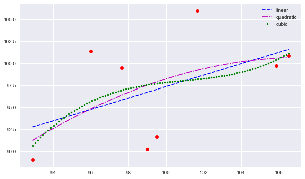

```python
plt.figure(figsize=(10, 6))
plt.plot(a[0], a[1], 'ro');
x = np.linspace(a[0].min(), a[0].max(), 100) # It creates 100 evenly distributed data points based on a[0] min to max
plt.plot(x, np.polyval(reg1, x), 'b--', label='linear') # polyval evaluates the regression result on each of the 100 data points
plt.plot(x, np.polyval(reg2, x), 'm-.', label='quadratic') # provided populating the results of each type of regression
plt.plot(x, np.polyval(reg3, x), 'g.', label='cubic')
plt.legend();
```

```python
reg8 = np.polyfit(a[0], a[1], 7)  # perfect regression
reg8
```

```
array([-1.29039390e-03,  9.05838435e-01, -2.72421055e+02,  4.54983739e+04,
       -4.55763606e+06,  2.73824001e+08, -9.13623538e+09,  1.30593702e+11])
```

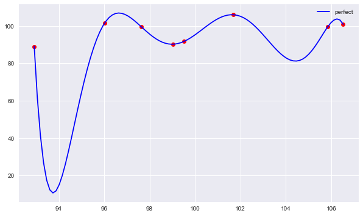

```python
plt.figure(figsize=(10, 6))
plt.plot(a[0], a[1], 'ro');
plt.plot(x, np.polyval(reg8, x), 'b', label='perfect')
plt.legend();
```

## Advance Numpy : Simulating Short Rate Processes

In this example, we are going to simulate the **Vasicek short rate model** using Python as well as NumPy and vectorization. The SDE of the model is given by:

$$ dr_t = \kappa(\theta - r_t)dt + \sigma dZ_t $$

A possible discretization of the model is given by

$$ r_t = r_s + \kappa (\theta - r_s) \Delta t + \sigma \sqrt{\Delta t} z_t $$

for $s = t - \Delta t$. $Z_t$ is a standard Brownian motion, $z$ a standard normally distributed rv.

```python
# All assumptions as Python variables

# model parameters
r0 = 0.01  # starting value
kappa = 1.0  # mean-reversion factor
theta = 0.025  # long-term mean
sigma = 0.01  # volatiltiy
T = 1.0  # time horizon in year fractions
# Monte Carlo parameters
I = 10  # number of paths
M = 15  # number of time intervals
dt = T / M  # length of time interval
```

### A Pure Python Version

Using import random

```python
def vasicek_python(I=I, M=M):
    paths = {}
    for i in range(I):
        path = [r0, ]
        for t in range(1, M + 1):
            r_t = path[t - 1] + kappa * (theta - path[t - 1]) * dt \
                    + sigma * dt ** 0.5 * random.gauss(0, 1)
            path.append(r_t)
        paths[i] = path
    return paths
```

### Breaking the Vasicek Simulation down

Let us start inside out:

```
1. r_t: It calculates the interest rate value on each point
    a. It takes the result of the previous simulation as input --> t -1
    b. It uses the outcome of a normal distribution with mean 0 and standard deviation of 1 to add the
        stochastic component
    c. The rest of the values are just parameters previously provided
    d. the result is appended to the path List
2. Re run r_t to get the next value in the path
3. Save all the values of the path in the paths dictionary
4. Run again a full path repeating steps 1 to 4
```

```python
paths = vasicek_python(10,15)
%time paths = vasicek_python(10,15)
```

```
Wall time: 997 µs
```

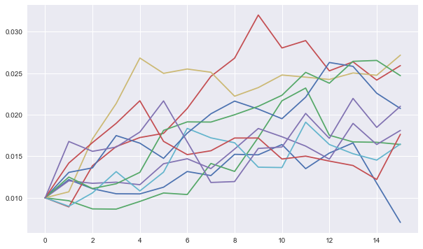

```python
plt.figure(figsize=(10, 6))
for i in paths.keys():
    plt.plot(paths[i])
```

### The Vectorized NumPy Version

Let us run the same function but this time using Numpy vectorization

```python
np.random.standard_normal(2)
```

[output not shown]

```python
def vasicek_numpy(I=I, M=M):
    paths = np.zeros((M + 1, I)) # matrix has M rows & I columns
    paths[0] = r0
    for t in range(1, M + 1):
        paths[t] = paths[t - 1] + kappa * (theta - paths[t - 1]) * dt \
                    + sigma * dt ** 0.5 * np.random.standard_normal(I)
    return paths
```

### Breaking down the simulation

Numpy uses vectors which offers the ability to run all the values of each step on 1

For 15 steps only 15 runs are needs which dramatically reduces processing time

```python
paths1 = vasicek_numpy(10,15)
%time paths1 = vasicek_numpy(10,15)
```

[output not shown]

```python
plt.figure(figsize=(10, 6))
plt.plot(paths1);
```

[output not shown]

### Individual Basic Functions

```python
x = [1,2,3]
```

```python
matrix = np.zeros((3 + 1, len(x)))
matrix[3, :] = x ** 3
matrix[2, :] = x ** 2
matrix[1, :] = x
matrix[0, :] = 1
```